# stat420 final proj

- Wenhao Tan - wenhaot2
- Ray Pan - yulinp3
- Yulan Ma - yulanma2

## Introduction

This data set contains the daily weather observations from numerous Australian weather stations in 2008. There are a total of 1685 observations and 19 columns of variables, including locations of the weather stations, minimum temperature, maximum temperature, wind gust speed, humidity, pressure, etc.

We took this data set from https://www.kaggle.com/jsphyg/weather-dataset-rattle-package. The original data set contains about 10 years of daily weather observations from many locations across Australia, and we took only the data of the year 2008.

We hope to understand the general weather in Australia so that we know when we should travel to Australia during the year for vacation.

## Methods

```r
library(readr)
library(faraway)
library(ggplot2)
library(lmtest)
library(caret)
library(ROCR)
library(knitr)
```

### Data

```r
weather_raw <- read_csv("weatherAUS.csv")
```

```
##
## i Use `spec()` for the full column specifications.
```

```r
# function to determine proportion of NAs in a vector
na_prop = function(x) {
  mean(is.na(x))
}

# check proportion of NAs in each column
sapply(weather_raw, na_prop)
```

```
##          Date      Location       MinTemp       MaxTemp      Rainfall
##    0.00000000    0.00000000    0.01020899    0.00866905    0.02241853
##   Evaporation      Sunshine   WindGustDir WindGustSpeed    WindDir9am
##    0.98746047    0.98151382    0.07098859    0.07055548    0.07263853
##    WindDir3pm  WindSpeed9am  WindSpeed3pm   Humidity9am   Humidity3pm
##    0.02906641    0.01214767    0.02105046    0.01824557    0.03098446
##   Pressure9am   Pressure3pm      Cloud9am      Cloud3pm       Temp9am
##    0.10356799    0.10331363    0.38421559    0.40807095    0.01214767
##       Temp3pm     RainToday  RainTomorrow
##    0.02481094    0.02241853    0.02245978
```

```r
# create dataset without columns containing more than 33% NAs
weather_clean = na.omit(weather_raw[, !sapply(weather_raw, na_prop) > 0.33])
# proportion of cleaned dataset to full dataset
nrow(weather_clean)/nrow(weather_raw)
```

```
## [1] 0.7763303
```

```r
weather_clean$Date=as.character(weather_clean$Date)
weather <- subset(weather_clean,startsWith(weather_clean$Date, "2008"))
#select the capital city to predict
weather_can<-weather[which(weather$Location=='Canberra'),]
head(weather_can, 5)
```

```
## # A tibble: 5 x 19
##   Date    Location MinTemp MaxTemp Rainfall WindGustDir WindGustSpeed WindDir9am
##   <chr>   <chr>      <dbl>   <dbl>    <dbl> <chr>               <dbl> <chr>
## 1 2008-0~ Canberra    13.6    34.2        0 NNE                    35 ESE
## 2 2008-0~ Canberra    14.3    35          0 ESE                    41 ESE
## 3 2008-0~ Canberra    15.9    23.4        0 ESE                    50 ESE
## 4 2008-0~ Canberra    16.7    25.3        0 ESE                    46 ESE
## 5 2008-0~ Canberra    12.1    27.5        0 NE                     35 SSE
## # ... with 11 more variables: WindDir3pm <chr>, WindSpeed9am <dbl>,
## #   WindSpeed3pm <dbl>, Humidity9am <dbl>, Humidity3pm <dbl>,
## #   Pressure9am <dbl>, Pressure3pm <dbl>, Temp9am <dbl>, Temp3pm <dbl>,
## #   RainToday <chr>, RainTomorrow <chr>
```

We cleaned up the data with NA omitted and took only the data of the year 2008 from the city Canberra.

### Modeling

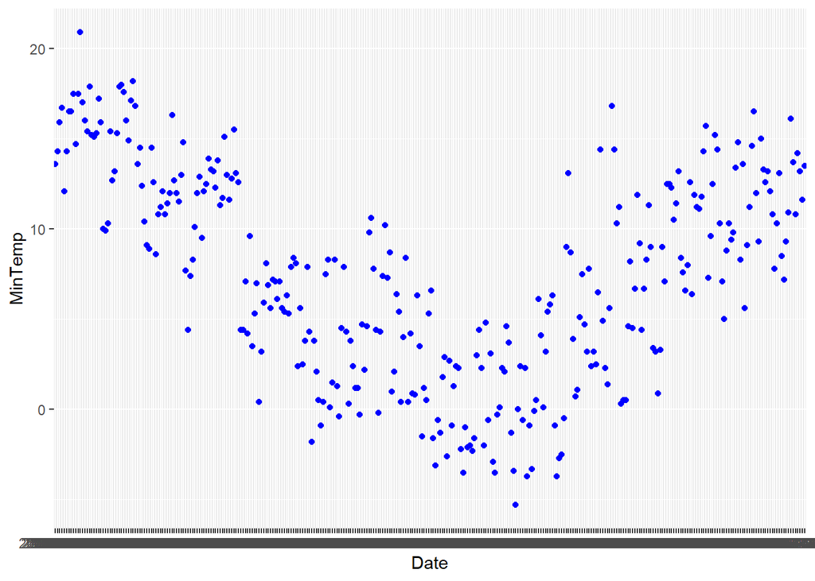

```r
#scatter plot of date vs. minimum temperature
ggplot(data = weather_can, aes(x = Date, y = MinTemp))+geom_point(color="blue")
```

```r
#remove the column of Location to avoid potential problems
weather_can=weather_can[,-2]
#fit the model with possible predictors
raw_mod_1<-lm(MinTemp ~ (RainToday + MaxTemp + Pressure3pm + Humidity3pm )^2, data=weather_can)
raw_mod_2<-lm(MinTemp ~ (RainToday + MaxTemp + Pressure3pm + Humidity3pm + WindGustSpeed)^2, data=weather_can)
raw_mod_3<-lm(MinTemp ~ (RainToday + MaxTemp + Pressure3pm + Humidity3pm + WindGustSpeed + Temp3pm)^2, data=weather_can)
#check if the added
anova(raw_mod_1, raw_mod_2)["Pr(>F)"][2,]
```

```
## [1] 0.0001745825
```

```r
anova(raw_mod_2, raw_mod_3)["Pr(>F)"][2,]
```

```
## [1] 0.001611429
```

```r
#backward selection on the model
select_2=step(raw_mod_2, direction="backward", trace=0)
select_3=step(raw_mod_3, direction="backward", trace=0)
adj_2=summary(select_2)$adj
adj_3=summary(select_3)$adj

bp_2=bptest(select_2)$p.value
sha_2=shapiro.test(resid(select_2))$p.value
bp_3=bptest(select_3)$p.value
sha_3=shapiro.test(resid(select_3))$p.value

calc_loocv_rmse<-function(model){
  sqrt(mean((resid(model) / (1 - hatvalues(model)))^2))
}
rmse_2=calc_loocv_rmse(select_2)
rmse_3=calc_loocv_rmse(select_3)

data=data.frame(
  c(adj_2, adj_3),
  c(bp_2, bp_3),
  c(sha_2, sha_3),
  c(rmse_2, rmse_3))

colnames(data)=c("adj r.squared", "bptest", "shapiro test", "LOOCV RMSE")
rownames(data)=c("Mod2", "Mod3")
kable(data)
```

|  | adj r.squared | bptest | shapiro test | LOOCV RMSE |
| --- | --- | --- | --- | --- |
| Mod2 | 0.7733356 | 0.0013179 | 0.4204914 | 2.790363 |
| Mod3 | 0.7856335 | 0.0756129 | 0.1261813 | 2.719191 |

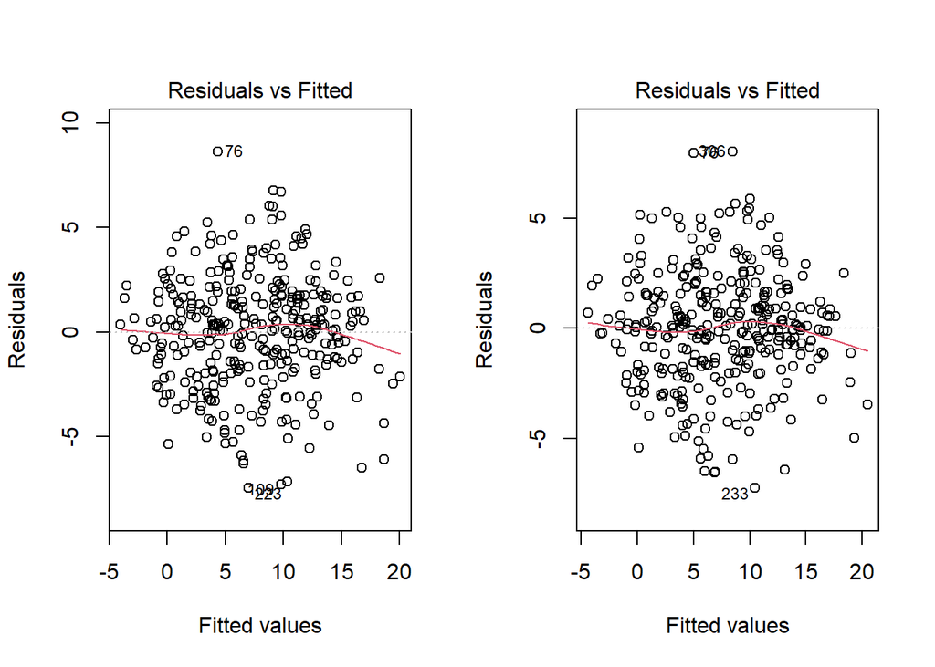

```r
par(mfrow=c(1,2))
plot(select_2, which=1)
plot(select_3, which=1)
```

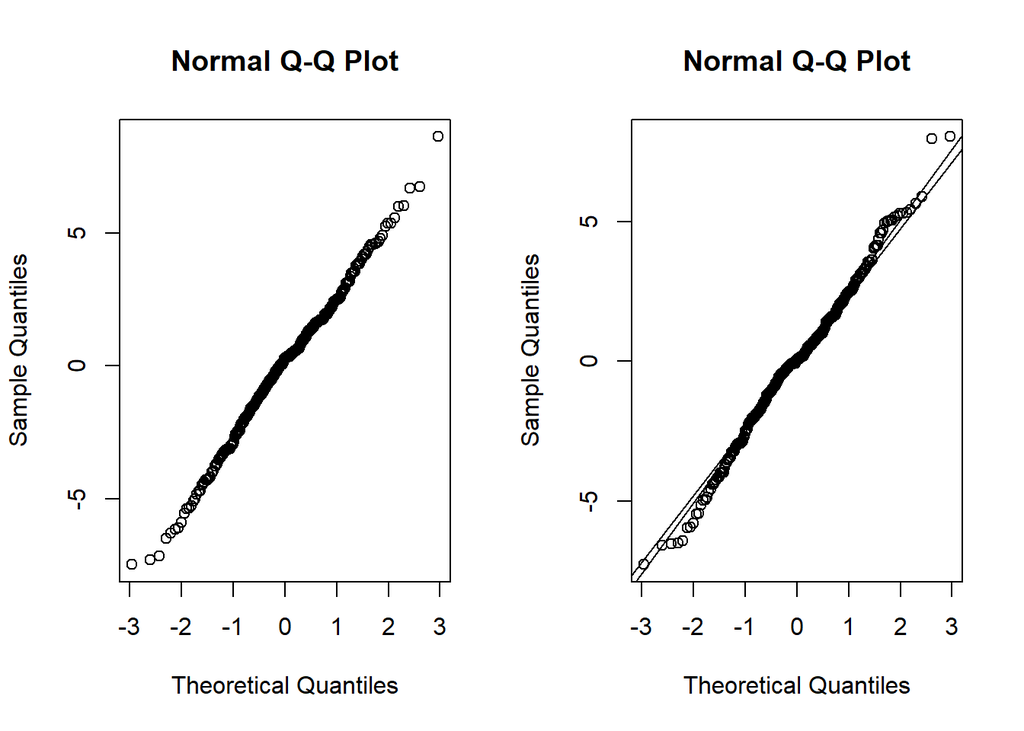

```r
par(mfrow=c(1,2))
qqnorm(resid(select_2))
qqnorm(resid(select_3))
qqline(resid(select_2))
qqline(resid(select_3))
```

The scatter plot makes sense because Australia is in the southern hemisphere and it has a relative low temperature in the middle of the year.

We thought the predictors in raw_mod_1 would be relative to the response variable “MinTemp”, but we were unsure whether the variables “WindGustSpeed” and “Temp3pm” have effects on “MinTemp”. We did two anova tests and found out that both the p-values are lower than 0.05, which means the two variables somewhat contribute to “MinTemp”, so we added these two variables in our model. We run several diagnostics, including bptest, shapiro test, and LOOCV RMSE calculation on our model and print a table for those values.

We also plot the fitted vs. residual and normal Q-Q plots as part of the diagnostic process. Some outliers were detected.

Here we selected another response variable “RainTomorrow”.

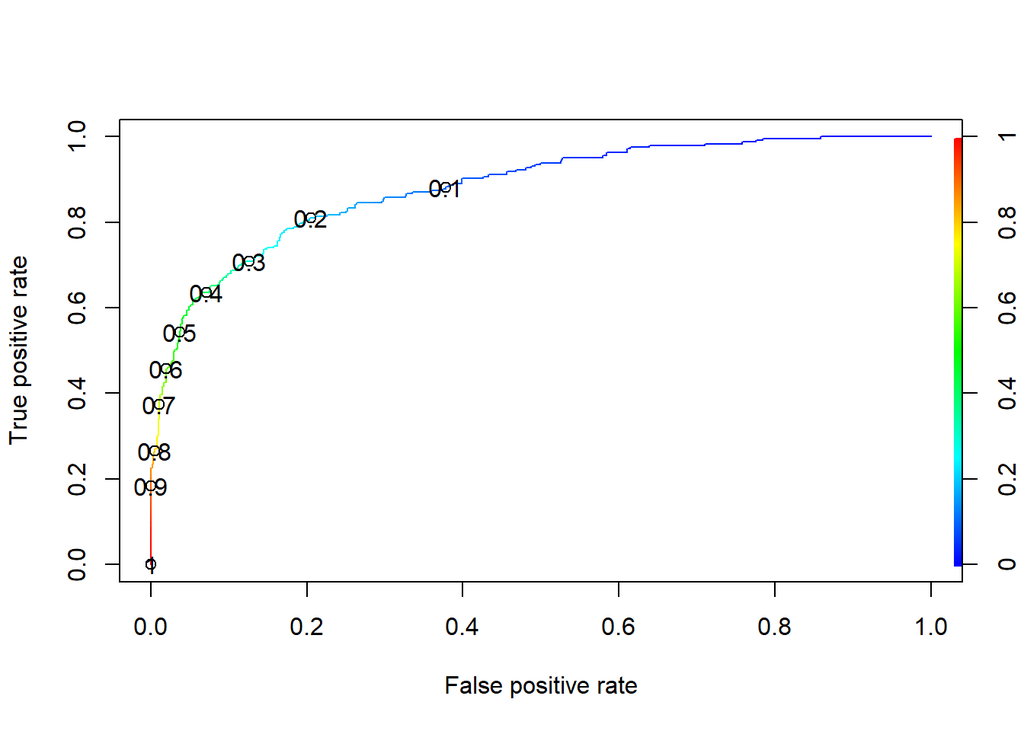

```r
set.seed(100)
#remove the column of Date to avoid potential problems
weather_new<-weather[,-1]
#change the binary factors into numeric values
weather_new$RainTomorrow[weather_new$RainTomorrow=="Yes"]<-1
weather_new$RainTomorrow[weather_new$RainTomorrow=="No"]<-0
weather_new$RainTomorrow<-as.numeric(weather_new$RainTomorrow)
#dividing the dataset into training(70%) and testing(30%)
we_trn_idx = sample(nrow(weather_new), size = 0.7 * nrow(weather_new))
we_trn = weather_new[we_trn_idx, ]
we_tst = weather_new[-we_trn_idx, ]
#fit glm model
fit<-glm(RainTomorrow~., data=we_trn, family="binomial")
prob=predict(fit, we_tst, type="response")

we_trn$pred<-fitted(fit)
pred<-prediction(we_trn$pred,we_trn$RainTomorrow)
perf<-performance(pred,"tpr","fpr")
plot(perf,colorize = T,print.cutoffs.at = seq(0.1,by = 0.1))
```

```r
#use 0.5 as the cutoff according to the ROC curve
pred = factor(ifelse(prob>0.5, "1", "0"))
confusionMatrix(pred, factor(we_tst$RainTomorrow))
```

```
## Confusion Matrix and Statistics
##
##           Reference
## Prediction   0   1
##          0 366  65
##          1  23  52
##
##                Accuracy : 0.8261
##                  95% CI : (0.7902, 0.8581)
##     No Information Rate : 0.7688
##     P-Value [Acc > NIR] : 0.0009934
##
##                   Kappa : 0.4406
##
##  Mcnemar's Test P-Value : 1.239e-05
##
##             Sensitivity : 0.9409
##             Specificity : 0.4444
##          Pos Pred Value : 0.8492
##          Neg Pred Value : 0.6933
##              Prevalence : 0.7688
##          Detection Rate : 0.7233
##    Detection Prevalence : 0.8518
##       Balanced Accuracy : 0.6927
##
##        'Positive' Class : 0
##
```

From the confusion matrix, we have an accuracy of 0.8261 when predicting whether there will be rain tomorrow with a sensitivity if 0.9409 and specificity of 0.4444, which are faily reasonable.